# ps5-rmarkdown

Kelly Le

2023-02-13

## Load and check data

### Question 2

```r
library(tidyverse)
gapminder <- read_delim("gapminder.csv")
```

The **gapminder** data contains 13055 rows and 25 columns.

### Question 3

```r
gapminder %>%
  sample_n(5) %>%
  knitr::kable()
```

| iso3 | name | iso2 | region | sub-region | intermediate-region | time | totalPopulation | fertilityRate | lifeExpectancy | childMortality | youthFemaleLiteracy | youthMaleLiteracy | adultLiteracy | GDP_PC | accessElectricity | agriculturalLand | agricultureTractors | cerealProduction | fertilizerHa | co2 | greenhouseGases | co2_PC | pm2.5_35 | battleDeaths |
| --- | --- | --- | --- | --- | --- | --- | --- | --- | --- | --- | --- | --- | --- | --- | --- | --- | --- | --- | --- | --- | --- | --- | --- | --- |
| KIR | Kiribati | KI | Oceania | Micronesia | NA | 1964 | 45399 | 6.634 | 49.145 | 172.8 | NA | NA | NA | NA | NA | 430 | 6 | NA | NA | 18.335 | NA | 0.40386 | NA | NA |
| CHL | Chile | CL | Americas | Latin America and the Caribbean | South America | 1960 | 8132990 | 4.697 | 57.219 | 157.1 | NA | NA | NA | 3611.9179 | NA | NA | NA | NA | NA | 13490.893 | NA | 1.65879 | NA | NA |
| TKM | Turkmenistan | TM | Asia | Central Asia | NA | 1960 | 1603258 | 6.590 | 54.471 | NA | NA | NA | NA | NA | NA | NA | NA | NA | NA | NA | NA | NA | NA | NA |
| MWI | Malawi | MW | Africa | Sub-Saharan Africa | Eastern Africa | 2016 | 17205289 | 4.407 | 62.681 | 50.0 | NA | NA | NA | 506.2497 | 11 | 56500 | NA | 2531749 | 24.50847 | 1298.118 | NA | 0.07545 | 0 | NA |
| UZB | Uzbekistan | UZ | Asia | Central Asia | NA | 1962 | 9113620 | 6.441 | 59.589 | NA | NA | NA | NA | NA | NA | NA | NA | NA | NA | NA | NA | NA | NA | NA |

## Descriptive statistics

### Question 1

```r
countries <- gapminder %>%
  group_by(`name`) %>%
  summarize(n = n_distinct(`name`)) %>%
  nrow()
iso2 <- gapminder %>%
  select(`iso2`) %>%
  summarize(n = n_distinct(`iso2`))
iso3 <- gapminder %>%
  select(`iso3`) %>%
  summarize(n = n_distinct(`iso3`))
```

The **gapminder** data contains 250 different countries, 249 different iso2, and 253 different iso3.

### Question 2

#### Part a

```r
gapminder %>%
  group_by(`iso2`) %>%
  select(`name`, `iso2`) %>%
  summarize(number_iso2 = n_distinct(`name`)) %>%
  arrange(desc(number_iso2)) %>%
  head(5) %>%
  knitr::kable()
```

| iso2 | number_iso2 |
| --- | --- |
| NA | 2 |
| AD | 1 |
| AE | 1 |
| AF | 1 |
| AG | 1 |

#### Part b

```r
gapminder %>%
  group_by(`name`, `iso3`) %>%
  filter(is.na(name)) %>%
  summarize(number_iso3 = n_distinct(`iso3`)) %>%
  arrange(desc(number_iso3)) %>%
  knitr::kable()
```

| name | iso3 | number_iso3 |
| --- | --- | --- |
| NA | CHANISL | 1 |
| NA | GBM | 1 |
| NA | KOS | 1 |
| NA | NLD_CURACAO | 1 |

### Question 3

```r
min_time <- gapminder %>%
  select(`time`) %>%
  arrange(`time`) %>%
  head(1)
max_time <- gapminder %>%
  select(`time`) %>%
  arrange(desc(`time`)) %>%
  head(1)
```

The min year in this data is 1960 and the max is 2019.

## CO2 emissions

### Question 1

```r
gapminder %>%
  group_by(time) %>%
  filter(is.na(co2), is.na(co2_PC), !is.na(time)) %>%
  summarize(na_co2 = sum(is.na(co2)), na_co2_PC = sum(is.na(co2_PC))) %>%
  select(time, na_co2, na_co2_PC) %>%
  arrange(desc(time)) %>%
  head(5) %>%
  knitr::kable()
```

| time | na_co2 | na_co2_PC |
| --- | --- | --- |
| 2019 | 217 | 217 |
| 2018 | 217 | 217 |
| 2017 | 217 | 217 |
| 2016 | 13 | 13 |
| 2015 | 13 | 13 |

### Question 2

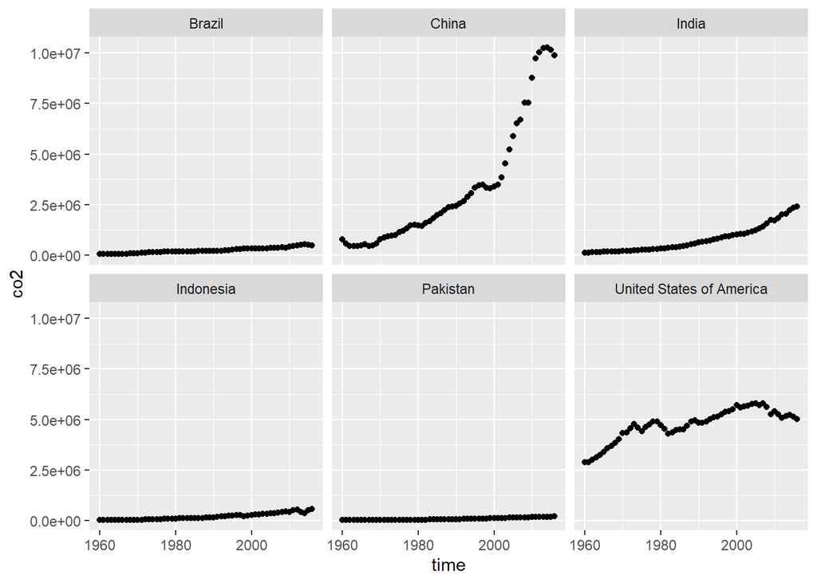

```r
gapminder %>%
  filter(!is.na(co2)) %>%
  filter(name == "United States of America" |
           name == "China" |
           name == "India" |
           name == "Indonesia" |
           name == "Pakistan" |
           name == "Brazil") %>%
  ggplot()+
  geom_point(aes(x = time, y = co2))+
  facet_wrap(~name)
```

All 6 countries shown in the plots are highly populated, but only the USA, China, and India seem to have a large role in CO2 emissions. The other countries have slopes that are close to 0.

### Question 3

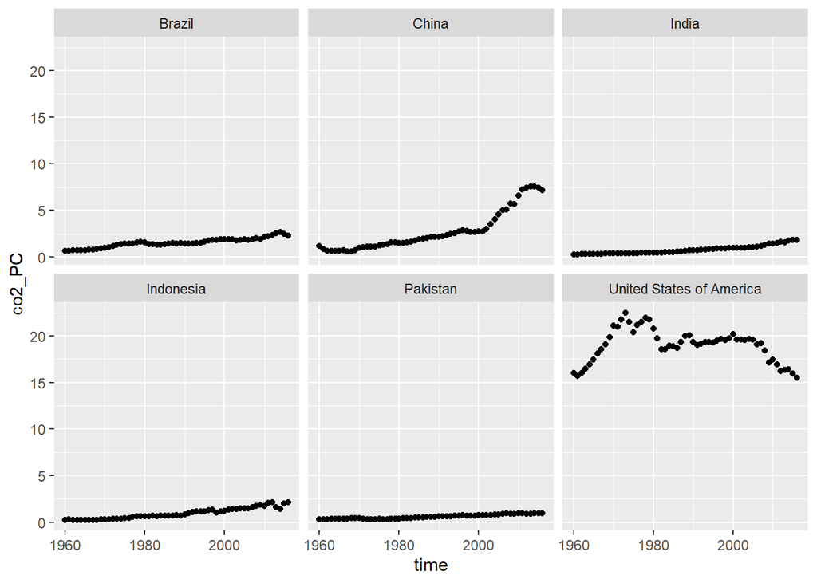

```r
gapminder %>%
  filter(!is.na(co2_PC)) %>%
  filter(name == "United States of America" |
           name == "China" |
           name == "India" |
           name == "Indonesia" |
           name == "Pakistan" |
           name == "Brazil") %>%
  ggplot()+
  geom_point(aes(x = time, y = co2_PC))+
  facet_wrap(~name)
```

These figures suggest a similar observation to the last question, except that it seems like India has less influence on CO2 emissions than previously thought. When capita is considered, it falls off. The USA and China have the most activity looking at CO2 per capita.

### Question 4

```r
gapminder %>%
  filter(!is.na(co2_PC), !is.na(region)) %>%
  group_by(region, time) %>%
  summarize(avg_co2 = mean(co2_PC)) %>%
  filter(time == "2016" | time == "1960") %>%
  knitr::kable()
```

| region | time | avg_co2 |
| --- | --- | --- |
| Africa | 1960 | 0.2908191 |
| Africa | 2016 | 1.2046730 |
| Americas | 1960 | 7.1501456 |
| Americas | 2016 | 4.8018156 |
| Asia | 1960 | 1.7446108 |
| Asia | 2016 | 6.4685498 |
| Europe | 1960 | 5.7702188 |
| Europe | 2016 | 6.6356861 |
| Oceania | 1960 | 2.7309630 |
| Oceania | 2016 | 4.5691181 |

### Question 5

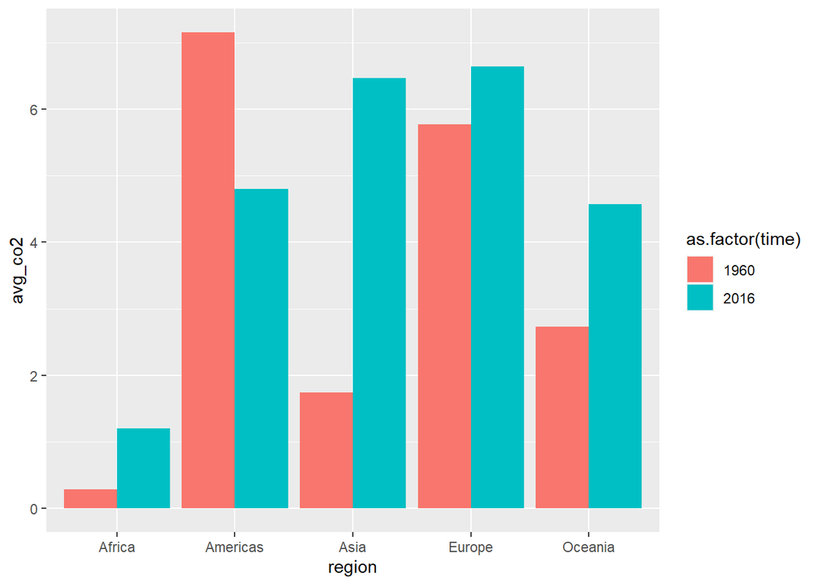

```r
gapminder %>%
  filter(!is.na(co2_PC), !is.na(region)) %>%
  group_by(region, time) %>%
  summarize(avg_co2 = mean(co2_PC)) %>%
  filter(time == "2016" | time == "1960") %>%
  ggplot() +
  geom_bar(stat = "identity", aes(x = region, y = avg_co2, fill = as.factor(time)), position = "dodge")
```

### Question 6

```r
top_bottom_3countries_co2_pc <- function(region_name){
  gapminder %>%
    filter(!is.na(co2_PC), !is.na(region), !is.na(name)) %>%
    filter(time == "2016") %>%
    filter(region == region_name) %>%
    filter(rank(desc(co2_PC))< 4|rank(co2_PC)< 4) %>%
    select(region, name, co2_PC) %>%
    arrange(desc(co2_PC)) %>%
    knitr::kable()
}
top_bottom_3countries_co2_pc("Africa")
```

| region | name | co2_PC |
| --- | --- | --- |
| Africa | South Africa | 8.48006 |
| Africa | Libya | 7.78851 |
| Africa | Seychelles | 6.39073 |
| Africa | Burundi | 0.04720 |
| Africa | Somalia | 0.04550 |
| Africa | Congo, Democratic Republic of the | 0.02564 |

```r
top_bottom_3countries_co2_pc("Americas")
```

| region | name | co2_PC |
| --- | --- | --- |
| Americas | Trinidad and Tobago | 31.84485 |
| Americas | United States of America | 15.50220 |
| Americas | Canada | 15.09006 |
| Americas | Honduras | 1.05847 |
| Americas | Nicaragua | 0.88709 |
| Americas | Haiti | 0.27469 |

```r
top_bottom_3countries_co2_pc("Asia")
```

| region | name | co2_PC |
| --- | --- | --- |
| Asia | Qatar | 38.90147 |
| Asia | Kuwait | 24.95251 |
| Asia | Bahrain | 22.22898 |
| Asia | Yemen | 0.39048 |
| Asia | Nepal | 0.33400 |
| Asia | Afghanistan | 0.24510 |

```r
top_bottom_3countries_co2_pc("Europe")
```

| region | name | co2_PC |
| --- | --- | --- |
| Europe | Gibraltar | 18.80401 |
| Europe | Luxembourg | 15.44261 |
| Europe | Faroe Islands | 13.09289 |
| Europe | Moldova, Republic of | 1.82554 |
| Europe | Albania | 1.57716 |
| Europe | Liechtenstein | 1.36327 |

```r
top_bottom_3countries_co2_pc("Oceania")
```

| region | name | co2_PC |
| --- | --- | --- |
| Oceania | New Caledonia | 19.26650 |
| Oceania | Australia | 15.53922 |
| Oceania | Palau | 12.61986 |
| Oceania | Kiribati | 0.58659 |
| Oceania | Vanuatu | 0.52700 |
| Oceania | Solomon Islands | 0.27232 |

## GDP per capita

### Question 1

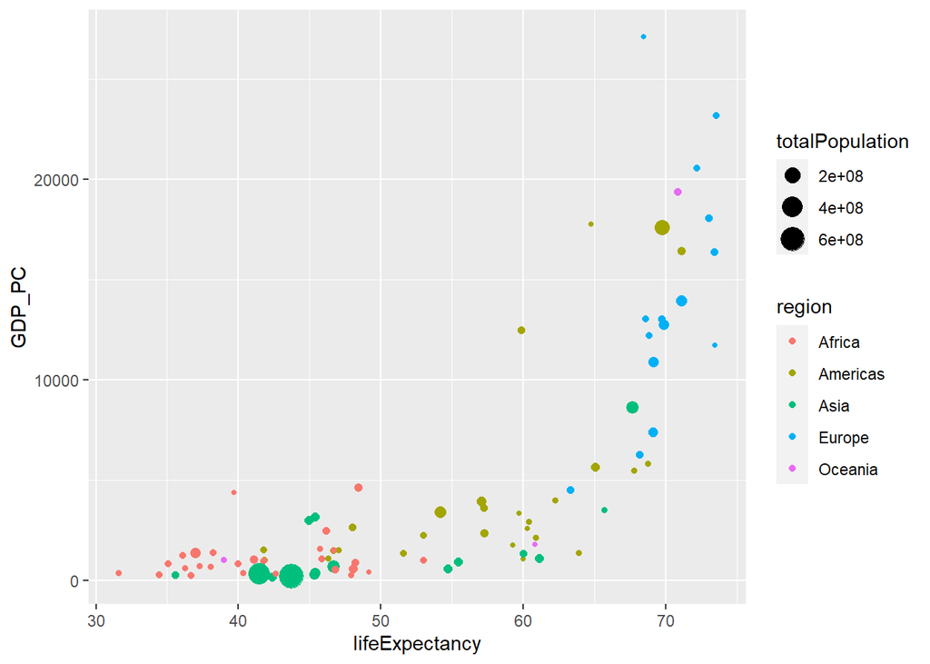

```r
gapminder %>%
  filter(!is.na(GDP_PC), !is.na(lifeExpectancy), !is.na(name)) %>%
  filter(time == "1960") %>%
  select(GDP_PC, lifeExpectancy, name, totalPopulation, region) %>%
  ggplot(aes(x = lifeExpectancy, y = GDP_PC))+
  geom_point(aes(color = region, size = totalPopulation))
```

Looking at this figure, I see that European countries seem to have higher life expectancy and GDP per capita than any other region and country. Asian countries tend to be the largest in population but are scattered when looking at GDP and life expectancy. African countries seem to have the lowest life expectancy and GDP.

### Question 2

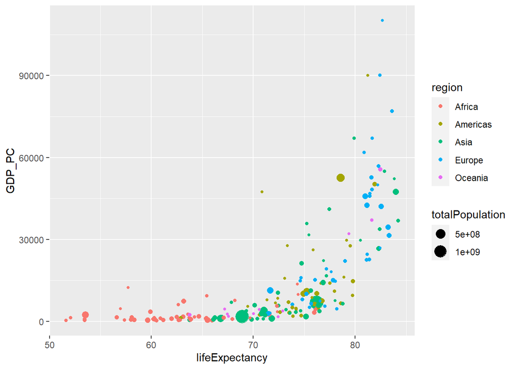

```r
gapminder %>%
  filter(!is.na(GDP_PC), !is.na(lifeExpectancy), !is.na(name)) %>%
  filter(time == "2016") %>%
  select(GDP_PC, lifeExpectancy, name, totalPopulation, region) %>%
  ggplot(aes(x = lifeExpectancy, y = GDP_PC))+
  geom_point(aes(color = region, size = totalPopulation))
```

### Question 4

```r
gapminder %>%
  group_by(region, time, lifeExpectancy) %>%
  filter(!is.na(lifeExpectancy), !is.na(region), !is.na(time)) %>%
  filter(time == "1960" | time == "2016") %>%
  group_by(region, time) %>%
  summarize(region_le = mean(lifeExpectancy)) %>%
  knitr::kable()
```

| region | time | region_le |
| --- | --- | --- |
| Africa | 1960 | 41.46600 |
| Africa | 2016 | 63.00138 |
| Americas | 1960 | 58.64651 |
| Americas | 2016 | 75.33572 |
| Asia | 1960 | 51.64931 |
| Asia | 2016 | 73.99026 |
| Europe | 1960 | 68.28254 |
| Europe | 2016 | 79.02642 |
| Oceania | 1960 | 56.39613 |
| Oceania | 2016 | 73.02476 |

### Question 5

```r
gapminder %>%
  filter(!is.na(lifeExpectancy), !is.na(region), !is.na(time)) %>%
  group_by(region) %>%
  mutate(prev = lag(lifeExpectancy), growth = lifeExpectancy - prev) %>%
  filter(!is.na(growth)) %>%
  summarize(avg_growth_le = mean(growth)) %>%
  arrange(desc(avg_growth_le)) %>%
  knitr::kable()
```

| region | avg_growth_le |
| --- | --- |
| Asia | 0.0113589 |
| Africa | 0.0074452 |
| Americas | 0.0061458 |
| Europe | 0.0040374 |
| Oceania | 0.0031857 |

I see that the life expectancy in Asia has grown the most and the least in Oceania.

### Question 6

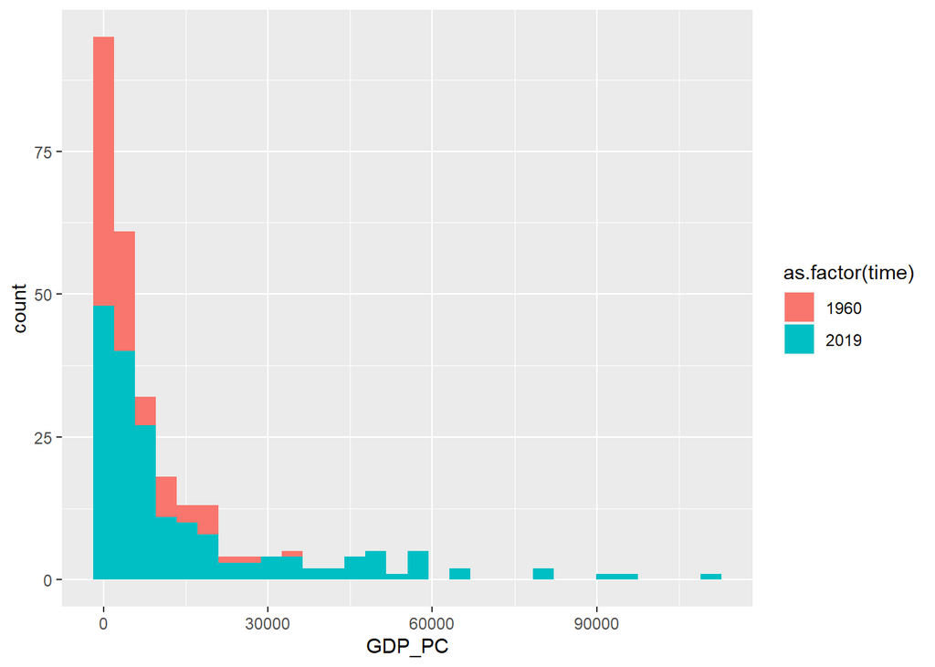

```r
gapminder %>%
  filter(!is.na(GDP_PC), !is.na(time), !is.na(name), !is.na(region)) %>%
  filter(time == "1960" | time == "2019") %>%
  group_by(name, region, GDP_PC, time) %>%
  ggplot(aes(x = GDP_PC, fill = as.factor(time)))+
  geom_histogram()
```

### Question 7

```r
US_le_1960 <- gapminder %>%
  filter(!is.na(lifeExpectancy), !is.na(time), !is.na(name)) %>%
  filter(time == "1960") %>%
  select(time, name, lifeExpectancy) %>%
  mutate(rank = rank(-lifeExpectancy)) %>%
  filter(name == "United States of America") %>%
  print.data.frame()
```

```
##   time                     name lifeExpectancy rank
## 1 1960 United States of America       69.77073   17
```

```r
US_le_2019 <- gapminder %>%
  filter(!is.na(lifeExpectancy), !is.na(time), !is.na(name)) %>%
  filter(time == "2019") %>%
  select(time, name, lifeExpectancy) %>%
  mutate(rank = rank(-lifeExpectancy)) %>%
  filter(name == "United States of America") %>%
  print.data.frame()
```

```
##   time                     name lifeExpectancy rank
## 1 2019 United States of America        78.7878   46
```

US rank in life expectancy in 1960 was 17 and in 2019 it was 46.

### Question 8

```r
countries_1960 <- gapminder %>%
  filter(!is.na(lifeExpectancy), !is.na(time), !is.na(name)) %>%
  filter(time == "1960") %>%
  summarize(total_countries = n_distinct(name))
US_le_1960_relative <- round((US_le_1960$rank/countries_1960), 2)

countries_2019 <- gapminder %>%
  filter(!is.na(lifeExpectancy), !is.na(time), !is.na(name)) %>%
  filter(time == "2019") %>%
  summarize(total_countries = n_distinct(name))
US_le_2019_relative <- round((US_le_2019$rank/countries_2019), 2)
```

US rank in life expectancy rank in 1960 was 0.09 and in 2019 it was 0.23.